# BISC 307, Lab 1: Ecoclimate & Public Health

Prof. Jackie Hatala Matthes, FA 2020

Lab: 29 October 2020

### Lab 1 Objectives

1. Visualize similarities and differences in Phoenix and Boston climates.
2. Use 30-year climatology to calculate daily departures from “normal” climate and assess whether Phoenix or Boston weather is more predictable.
3. Learn to read messy, real spreadsheet data files into R.
4. Use the five tidyverse verbs - filter, arrange, select, mutate, and summarize - as functions to manipulate real data.
5. Investigate patterns in individually experienced temperatures (IETs) in Phoenix on a sub-daily timescale by neighborhood, age, and income.

### 1. Introduction: Packages, Data

In this lab, we’ll learn to work with Rstudio to load and visualize a dataset describing the climates of Boston and Phoenix. Our objectives for today will build on what you read in preparation for this lab, [Sections 3.1-3.6 from the R for Data Science](http://r4ds.had.co.nz/data-visualisation.html#introduction-1) book.

Today we will use functions from the `tidyverse` package. You should have already installed `tidyverse` during your Pre-Lab 1 R4DS exercises. After you’ve run the `install.packages()` once you can load that particular package with the `library()` function. You’ll need to load the libraries that you’d like to use every time you restart Rstudio, which helps to save space on your computer.

```r
# Only run this next line ONCE EVER without the # in front:
#install.packages("tidyverse")
library(tidyverse)
library(lubridate)
```

Next we will read our data into R. In the second half of lab we’ll load data from a spreadsheet csv file, but for now we’ll work with pre-formatted data in R. To load the .RData file, we use the `load()` function. You can also do this step by going to `File > Open File` on the Rstudio top menu bar, and then selecting the .Rdata file to load. However, it’s better to do this by writing out the actual code, so that you can save it and all of your steps are reproducible.

```r
# Load .RData file with Boston & Phoenix climate data
load("data/BOSPHO_climate.RData")
```

This should create two objects in your Rstudio “Environment” panel (upper right box of Rstudio) called `BOS_climate` and `PHO_climate`. Both are data frame objects with rows as observations and 5 columns with the variables. We can take a look at the first few rows of the data frame by running:

```r
BOS_climate
```

```
## # A tibble: 27,893 x 5
##    station      date        tmax  tmin precip
##    <chr>        <date>     <int> <int>  <dbl>
##  1 BOSTON MA US 1941-01-01    39    28   0
##  2 BOSTON MA US 1941-01-02    36    24   0.03
##  3 BOSTON MA US 1941-01-03    40    31   0.07
##  4 BOSTON MA US 1941-01-04    39    30   0.85
##  5 BOSTON MA US 1941-01-05    30    21   0
##  6 BOSTON MA US 1941-01-06    30    19   0
##  7 BOSTON MA US 1941-01-07    30    14   0
##  8 BOSTON MA US 1941-01-08    30    14   0
##  9 BOSTON MA US 1941-01-09    33    18   0.01
## 10 BOSTON MA US 1941-01-10    33    24   0
## # … with 27,883 more rows
```

We can see the data frame dimensions (numbers of rows and columns) in addition to the variable (column) names and the class of the data in each variable. In this data frame, the `station` variable is a character class (letters), the `date` is a date class, `tmax` and `tmin` are integers, and `precip` is a numeric decimal class.

Now let’s use ggplot to visualize the maximum temperature in Boston over the whole time period.

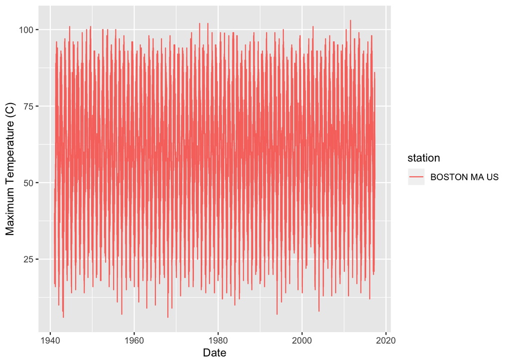

```r
# Plot Boston maximum temperature
ggplot(data = BOS_climate) +
  geom_line(mapping = aes(x = date, y = tmax, col=station)) +
  labs(x = "Date", y = "Maximum Temperature (C)")
```

The syntax of ggplot and its arguments should look familiar from the R4DS reading. The first argument to ggplot identifies the data frame for plotting, and `geoms` are added that specify how the data are mapped onto the plot. For this plot, we are mapping `date` onto the x-axis, `tmax` onto the y-axis, and coloring the lines by station. We can also change the axis labels by adding the `labs` function to the `ggplot` list.

**Code Challenge 1: Within your group, create a plot that shows the daily precipitation values for Boston.**

### 2. Climatology

Now we’ll aggregate these data into a climatology to determine whether any one day, month, or year is different from the long-term normal value. A 30-year averaging period is typically used in climatology because this period captures many years that can vary with cyclical patterns like El Niño.

Climatological periods are defined by the World Meteorological Organization as a 30-year interval that starts with a year that ends in a 1 and end on a year that ends on a 0, so the nearest climatological period to 2019 (the last complete year) is 1981-2010. This is called a climatological “normal” because we use it to evaluate whether any particular value is different from normal conditions.

The first step for our climatology is to clip our data to 1981-2010. To do this, we’ll use the `filter()` function from the `tidyverse` package. Almost all of the `tidyverse` data processing functions have a similar structure to arguments (you’ll read more about these in detail in PreLab 2):

1. The first argument is the data frame we’re using.
2. The second argument describes how we’d like to change the data.

Here, the second argument is using a function from the `lubridate` package that we loaded at the beginning – `year()` – to return just the year from the `date` variable. We’re using the `year()` function to only select the years that are greater than 1980 and less than 2011. (Equivalently, we could have written `year(date) >= 1981 & year(date) <= 2010` with less than/greater than or equal for this second argument).

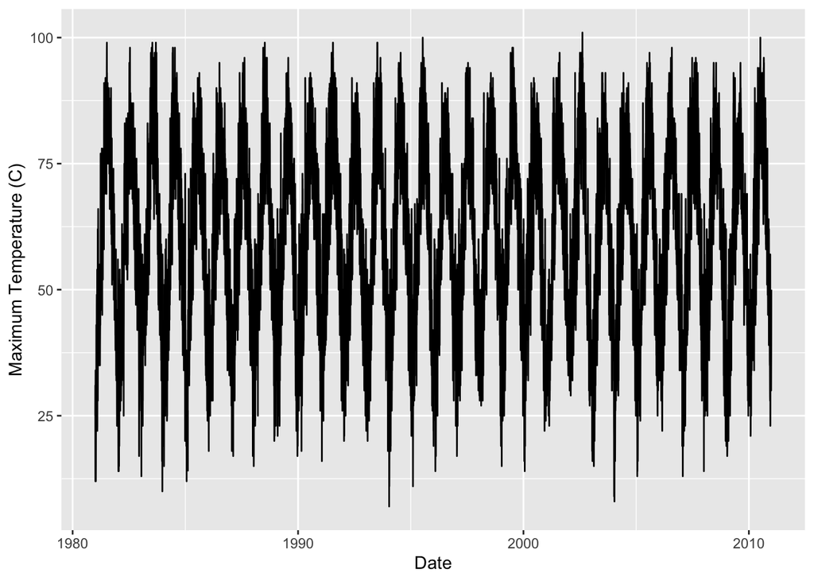

```r
# Clip out 1981-2010 in BOS from the climate data
BOS_climrecent <- filter(BOS_climate, year(date) > 1980 & year(date) < 2011)

# Plot Phoenix and Boston maximum temperature, 1981-2010
ggplot(data = BOS_climrecent) +
  geom_line(mapping = aes(x = date, y = tmax)) +
  labs(x = "Date", y = "Maximum Temperature (C)")
```

The next step is to take the 30-year average for maximum temperature on each day. We’ll do this with a set of three functions from the `tidyverse`:

1. `mutate()` to add a column with just the month & day for each date (removing year)
2. `group_by()` to define the month-day column as the grouping variable
3. `summarize()` to calculate the 30-year statistics over the grouping variable

```r
# Add a new column with just month & day from date
BOS_climrecent_v2 <- mutate(BOS_climrecent,
                            month_day = format(date, "%m-%d"))

# Look at the new month_day column
BOS_climrecent_v2
```

```
## # A tibble: 10,957 x 6
##    station      date        tmax  tmin precip month_day
##    <chr>        <date>     <int> <int>  <dbl> <chr>
##  1 BOSTON MA US 1981-01-01    25    13   0    01-01
##  2 BOSTON MA US 1981-01-02    31    12   0.22 01-02
##  3 BOSTON MA US 1981-01-03    15     6   0    01-03
##  4 BOSTON MA US 1981-01-04    12    -4   0    01-04
##  5 BOSTON MA US 1981-01-05    24    -4   0    01-05
##  6 BOSTON MA US 1981-01-06    29    16   0    01-06
##  7 BOSTON MA US 1981-01-07    34    16   0.19 01-07
##  8 BOSTON MA US 1981-01-08    18    11   0    01-08
##  9 BOSTON MA US 1981-01-09    19    10   0    01-09
## 10 BOSTON MA US 1981-01-10    23    11   0.08 01-10
## # … with 10,947 more rows
```

```r
# Group data frame by month_day for climatology
# (we want to average over all 30 years for max temp on Jan-01, Jan-02, etc.)
BOS_clim_grouped <- group_by(BOS_climrecent_v2, month_day)

# Calculate 30-year average tmax for each day of the year
BOS_tmax30yr <- summarize(BOS_clim_grouped,
                          tmax_mean = mean(tmax, na.rm=TRUE))
```

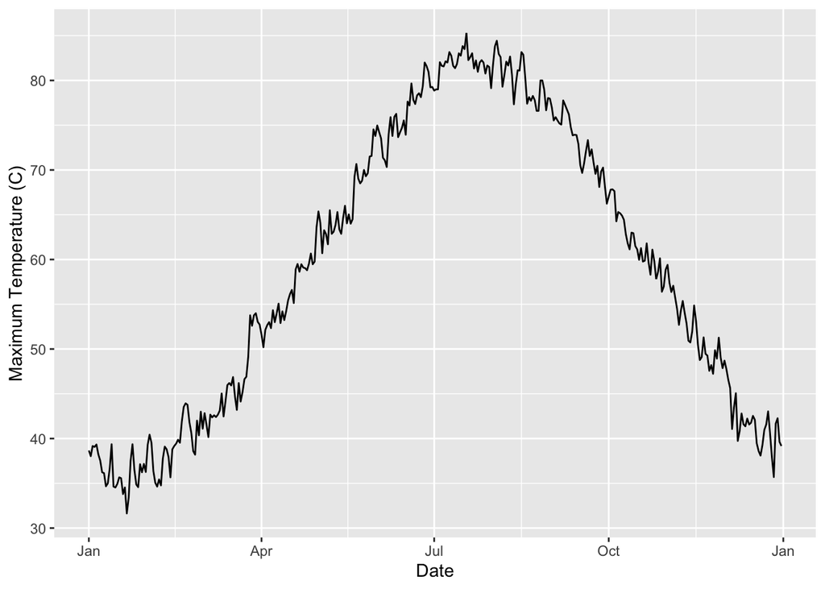

```r
# Plot Boston normal maximum temperature, climatology 1981-2010
ggplot(data = BOS_tmax30yr) +
  geom_line(mapping = aes(x = as.Date(month_day, format = "%m-%d"),
                          y = tmax_mean)) +
  labs(x = "Date", y = "Maximum Temperature (C)") +
  scale_x_date(date_labels = "%b")
```

Whenever we are writing a set of processing steps with intermediate objects (e.g., `BOS_climrecent` and `BOS_climrecent_v2`), it’s good to think about putting those steps together into neater blocks of code by using `pipes %>%` from the `maggritr` package (included in the `tidyverse`). A pipe takes the output from one line and “pipes” it to the following line without creating an intermediate object.

For example, we can re-write the steps from above to find the 30-year Boston climatology using pipes:

```r
# Summarize 30-year 1981-2010 max temperature
BOS_tmaxClimatology <- BOS_climate %>%
  filter(year(date) > 1980 & year(date) < 2011) %>%
  mutate(month_day = format(date, "%m-%d")) %>%
  group_by(month_day) %>%
  summarize(tmax_mean = mean(tmax, na.rm=TRUE))
```

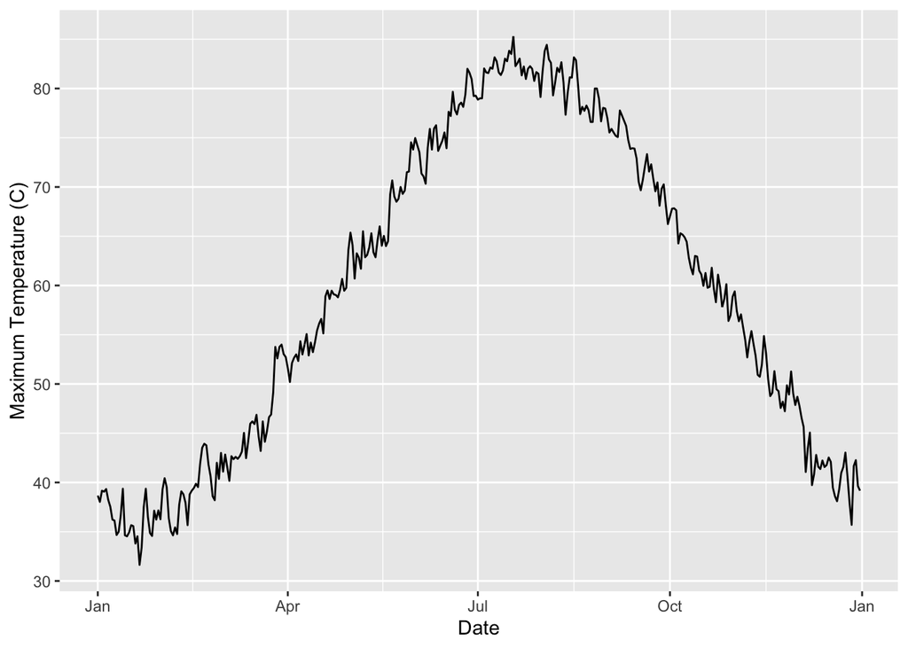

```r
# Plot Boston climatological maximum temperature, 1981-2010
ggplot(data = BOS_tmaxClimatology) +
  geom_line(mapping = aes(x = as.Date(month_day, format = "%m-%d"),
                          y = tmax_mean)) +
  labs(x = "Date", y = "Maximum Temperature (C)") +
  scale_x_date(date_labels = "%b")
```

**Code Challenge 2: Repeat the steps that we used here to calculate and visualize the 30-year climatological mean daily maximum temperature for Phoenix. BEFORE YOU START CODING, outline and review the steps that you are going to take within your group.**

Next, we’ll calculate the difference between the daily weather data of maximum temperature and the climatological 30-year mean maximum temperature to see when values differ from normal.

The first step is to attach a column with the 30-year mean daily values onto the original daily weather data frame. We’ll use the `left_join()` function to connect the 30-year climatology by matching up the day-month in both datasets. We’ll learn more about `joins` in detail later on. Then, we’ll use `mutate()` to make a new column that is tmax minus tmax_mean for the difference between the actual temperature and the 30-year mean temperature on that day.

```r
# Join 30-year mean daily max temp to all yearly data and calculate difference
BOS_tmaxDiff <- BOS_climate %>%
  filter(year(date) > 1980 & year(date) < 2011) %>%
  mutate(month_day = format(date, "%m-%d")) %>%
  left_join(BOS_tmaxClimatology, by = "month_day") %>%
  mutate(tmax_diff = tmax - tmax_mean)

# Look at the new data frame
BOS_tmaxDiff
```

```
## # A tibble: 10,957 x 8
##    station      date        tmax  tmin precip month_day tmax_mean tmax_diff
##    <chr>        <date>     <int> <int>  <dbl> <chr>         <dbl>     <dbl>
##  1 BOSTON MA US 1981-01-01    25    13   0    01-01          38.7    -13.7
##  2 BOSTON MA US 1981-01-02    31    12   0.22 01-02          38.0     -7.03
##  3 BOSTON MA US 1981-01-03    15     6   0    01-03          39.2    -24.2
##  4 BOSTON MA US 1981-01-04    12    -4   0    01-04          39.1    -27.1
##  5 BOSTON MA US 1981-01-05    24    -4   0    01-05          39.3    -15.3
##  6 BOSTON MA US 1981-01-06    29    16   0    01-06          38.2     -9.23
##  7 BOSTON MA US 1981-01-07    34    16   0.19 01-07          37.5     -3.53
##  8 BOSTON MA US 1981-01-08    18    11   0    01-08          36.2    -18.2
##  9 BOSTON MA US 1981-01-09    19    10   0    01-09          36.1    -17.1
## 10 BOSTON MA US 1981-01-10    23    11   0.08 01-10          34.7    -11.7
## # … with 10,947 more rows
```

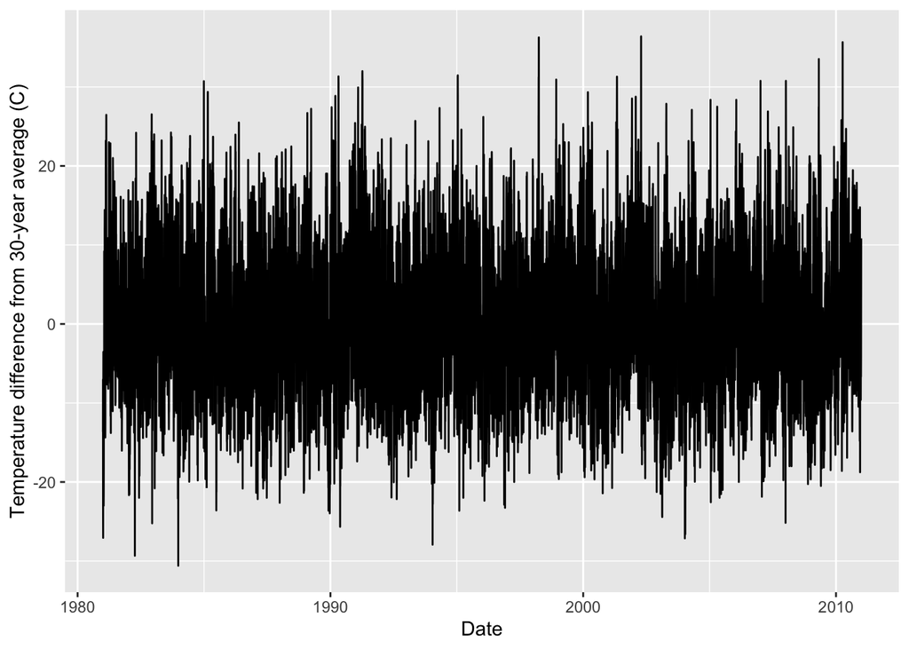

```r
# Plot Boston difference from climatological maximum temperature, 1981-2010
ggplot(data = BOS_tmaxDiff) +
  geom_line(mapping = aes(x = date, y = tmax_diff)) +
  labs(x = "Date", y = "Temperature difference from 30-year average (C)")
```

Now let’s do the same steps to calculate the Phoenix daily departures in maximum temperature from the 30-year climatology:

```r
# Summarize 30-year 1981-2010 max temperature
PHO_tmaxClimatology <- PHO_climate %>%
  filter(year(date) > 1980 & year(date) < 2011) %>%
  mutate(month_day = format(date, "%m-%d")) %>%
  group_by(month_day) %>%
  summarize(tmax_mean = mean(tmax, na.rm=TRUE))
# Join 30-year mean daily max temp to all yearly data and calculate difference
PHO_tmaxDiff <- PHO_climate %>%
  filter(year(date) > 1980 & year(date) < 2011) %>%
  mutate(month_day = format(date, "%m-%d")) %>%
  left_join(PHO_tmaxClimatology, by = "month_day") %>%
  mutate(tmax_diff = tmax - tmax_mean)
```

### 3. Weather predictability

Departures from mean climate are important for ecology, including human health. For example, in Boston our infrastructure is built to handle large amounts of snow during the winter, but the same sized snowstorm further South could bring things to a standstill for days. Similarly, heat stress is an important factor when considering climate change: if infrastructure is built for a particular temperature within a city, unexpected temperature departures can have devastating impacts for people who cannot quickly adjust temperature conditions in their homes.

We can assess the predictability of weather within a location by comparing daily weather to the 30-year climatology. We’ll define unpredictability as larger deviations from the mean climatology. We’ve already calculated the difference between daily maximum temperatures and their 30-year average. To visualize this difference, we can look at a probability density of the departures from the long-term average:

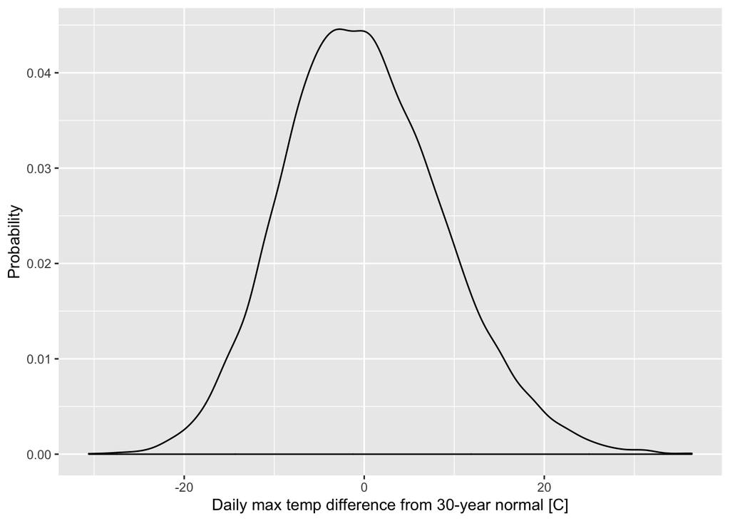

```r
# Plot Boston difference from climatological maximum temperature, 1981-2010
ggplot(data = BOS_tmaxDiff) +
  geom_density(mapping = aes(x = tmax_diff)) +
  labs(x = "Daily max temp difference from 30-year normal [C]", y = "Probability")
```

We can also get values for the mean, standard deviation, and different percentiles of the climatological departures:

```r
mean(BOS_tmaxDiff$tmax_diff) # mean departure (basically zero)
```

```
## [1] 1.408129e-16
```

```r
sd(BOS_tmaxDiff$tmax_diff) # standard deviation
```

```
## [1] 8.858988
```

```r
quantile(BOS_tmaxDiff$tmax_diff, c(0.05, 0.95)) # 5% tails of the probability values
```

```
##        5%       95%
## -13.80000  15.33333
```

The above plot and quantile calculation shows that in Boston, there about a 5% chance of having a day that is about 14-15 degrees warmer or colder than average. This is a small but non-negligible probability. We can use the probability density for Boston maximum temperature departures as a benchmark to assess whether Phoenix’s maximum temperatures are more or less predictable than Boston’s.

**Code Challenge 3: Produce a plot that shows the probability density for the difference between daily maximum tempearture and the 30-year climatological mean for Phoenix. Comparing the probability densities of maximum temperature departures for Boston and Phoenix, which city is more likely to experience an “abnormally hot” day?**

### 4. Individually Exerienced Temperatures (IETs)

Now we’ll investigate a [dataset](https://doi.org/10.6073/pasta/cba2173a40671a8a350c772f3da3214f) of Individually Exerienced Temperatures (IETs) from the [Central Arizona-Phoenix (CAP) Long-Term Ecological Research (LTER) site](https://sustainability.asu.edu/caplter/). You can read more details about the functions that we’ll use here in the sections on Data Transformation, [Sections 5.1-5.6 from the R for Data Science book](http://r4ds.had.co.nz/transform.html), which you’ll work with in PreLab 2.

The IETs data are stored as `.csv` files, which stands for comma-separated values. `csv` files are a plain text format for storing spreadsheets, and because they are plain text (for example in contrast to an Excel workbook) they are more reproducible because you can open files with any computer text editor. You can also store Excel and Google sheets as `csv` files, which is the preferred storage format for reproducible research because versions of Excel and Google sheets softwares change.

To load a csv file into Rstudio, we’ll use `read_csv()` from the `tidyverse`. R also has a base function called `read.csv()` that doesn’t require the `tidyverse` package, but `read_csv()` has a few advantages here. Helpfully, `read_csv()` preserves data classes, and recognizes dates and times.

The IETs dataset has five different csv files, and you can read more about each file in `IET_metadata.txt` file included in the `data/` directory of this repository. The metadata contains important information for interpreting the data, for example the meaning of column names, units, etc. Here we will only work with two of the csv files from this dataset - the main IET dataset and the background participant survey - but you can use the other files, if you’d like, for your lab report.

[output not shown]

There are LOTS of data about participant background characteristics (on age, income, race, etc.) that correspond to individual survey questions. If you’d like to extend this lab for your final project, you can read the `IET_metadata.txt` to incorporate data from this study to the IETs, but for now we’ll focus on differences by neighborhood and time of day.

### 5. Visualizing differences in IETs by neighborhood and time of day

First we’ll examine the differences in IETs grouped by neighborhood using the `tidyverse` Data Transformation verbs. The IETs column for `Subject ID` includes the neighborhood, but is stuck to the participant ID within each neighborhood. To group data by neighborhood, we’ll use `mutate()` to create a new column with just neighborhood and second new column with just participant ID.

To separate the neighborhood from `Subject ID`, we’ll use a function called string subset `str_sub()` from the `stringr` package. This function clips out a string (a set of letters or characters) based on location of the clip. For example, the `Subject ID` string in the first row of the IETs data frame is `1A`, where we want to clip out the first character `1` (location 1) into the new neighborhood column and the second character `A` (location 2) into the new ID column.

We’ll use these `stringr` functions now, but you shouldn’t worry about understanding all the details: the main point of this part of lab is to plot and be exposed to the data transformation verbs, but we can’t avoid `stringr` in order to use this dataset. Remember that learning R is like learning a new language, and you can think about the `stringr` commands in this lab as an immersion experience where you might not understand every detail, but can focus on the purpose of how these functions are helping us to tidy the data.

```r
# Make a new data frame with columns for neighborhood and ID
# We need to surround Subject ID with backticks `` (to the left of the 1 on your computer keyboard) in mutate because it has a space in the name
# Function str_sub(column name, from character, to character)
IETs_nbh <- mutate(IETs,
                   neighborhood = str_sub(`Subject ID`,1,1),
                   ID = str_sub(`Subject ID`,2,2))

# Look at the new data frame
IETs_nbh
```

```
## # A tibble: 3,360 x 5
##    `Subject ID` period        temperature neighborhood ID
##    <chr>        <chr>               <dbl> <chr>        <chr>
##  1 1A           Sat, 8pm-12am        25.1 1            A
##  2 1P           Sat, 8pm-12am        26.8 1            P
##  3 1E           Sat, 8pm-12am        27.2 1            E
##  4 1B           Sat, 8pm-12am        26.8 1            B
##  5 2N           Sat, 8pm-12am        NA   2            N
##  6 3A           Sat, 8pm-12am        NA   3            A
##  7 1T           Sat, 8pm-12am        26.9 1            T
##  8 1C           Sat, 8pm-12am        28.7 1            C
##  9 1D           Sat, 8pm-12am        32.7 1            D
## 10 1G           Sat, 8pm-12am        26.7 1            G
## # … with 3,350 more rows
```

Now we can use `ggplot` to visualize IETs across the five neighborhoods. When we make the ggplot, R will warn us that it removed values that were NA in the data, but this is okay for our purposes.

```
## Warning: Removed 141 rows containing non-finite values (stat_boxplot).
```

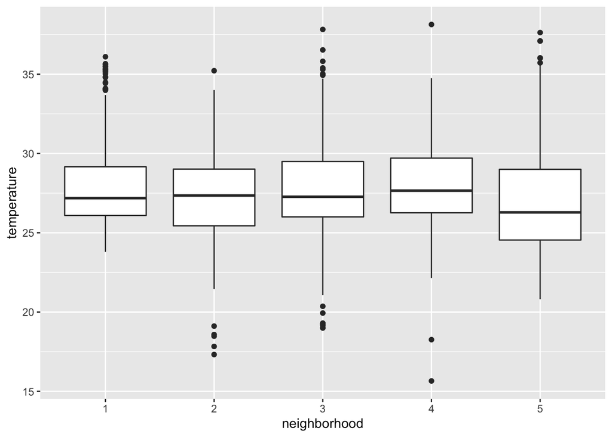

```r
# Plot IETs by neighborhood, across all time periods
ggplot(IETs_nbh) +
  geom_boxplot(mapping = aes(x = neighborhood, y = temperature))
```

It sort of looks like the IETs from neighborhood 5 are lower than those from the other neighborhoods. However, this plot summarizes the data across all times of day, which could introduce varibility into this relationship.

To look at differences in IETs by time of day, we’ll summarize the data by each time period (12am-4am, 4am-8am, etc.). Like we did for `Subject ID`, we’ll use `mutate()` to separate the time period and day of the week from the `period` column of `IETs_nbh`. We’ll use the function `str_split_fixed()` from the `stringr` package to separate the period strings into two columns - one for day of week (dow) and one for hours (hrs) - at the “,” within each string.

```r
# Make new columns for day of week (dow) and time period (hrs)
# str_split_fixed(column name, "separator character",
#                 number of columns to expect)[,column number]
IETs_nbh_time <- mutate(IETs_nbh,
                 dow = str_split_fixed(period, ", ", n = 2)[,1],
                 hrs = str_split_fixed(period, ", ", n = 2)[,2])

# Look at the new data frame
IETs_nbh_time
```

```
## # A tibble: 3,360 x 7
##    `Subject ID` period        temperature neighborhood ID    dow   hrs
##    <chr>        <chr>               <dbl> <chr>        <chr> <chr> <chr>
##  1 1A           Sat, 8pm-12am        25.1 1            A     Sat   8pm-12am
##  2 1P           Sat, 8pm-12am        26.8 1            P     Sat   8pm-12am
##  3 1E           Sat, 8pm-12am        27.2 1            E     Sat   8pm-12am
##  4 1B           Sat, 8pm-12am        26.8 1            B     Sat   8pm-12am
##  5 2N           Sat, 8pm-12am        NA   2            N     Sat   8pm-12am
##  6 3A           Sat, 8pm-12am        NA   3            A     Sat   8pm-12am
##  7 1T           Sat, 8pm-12am        26.9 1            T     Sat   8pm-12am
##  8 1C           Sat, 8pm-12am        28.7 1            C     Sat   8pm-12am
##  9 1D           Sat, 8pm-12am        32.7 1            D     Sat   8pm-12am
## 10 1G           Sat, 8pm-12am        26.7 1            G     Sat   8pm-12am
## # … with 3,350 more rows
```

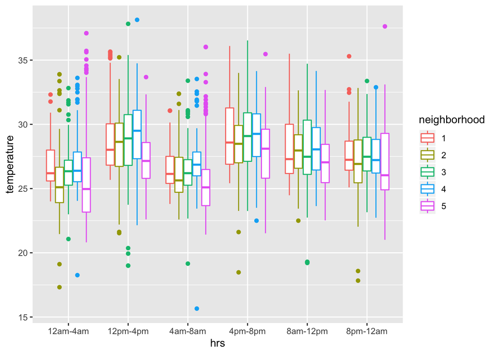

```r
# Plot: what is not ideal about this figure?
ggplot(IETs_nbh_time) +
  geom_boxplot(mapping = aes(x = hrs, y = temperature, color = neighborhood))
```

*Note:* In practice, instead of using `mutate()` twice to create `IETs_nbh` and then `IETs_nbh_time`, we could have done a single `mutate()` function that added all the columns at once, but I broke these apart so that we could focus on individual steps. Whenever you are writing your code, after you get something that works, it’s helpful to look back through what you did to see whether you could have combined steps to be more efficient with pipes `%>%` or by using a function only once.

We can fix the order of the x-axis categories to be sorted by time (instead of alphanumeric sorted) by adding a `scale_x_discrete()` function to ggplot. This will redefine the order of the categories that we want to display.

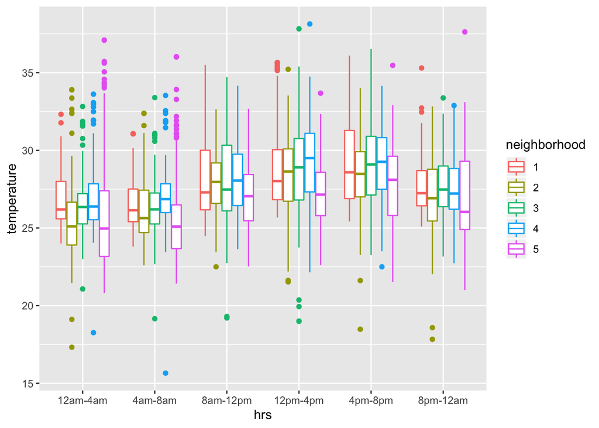

```r
# Better Plot
ggplot(IETs_nbh_time) +
  geom_boxplot(mapping = aes(x = hrs, y = temperature, color = neighborhood)) +
  scale_x_discrete(limits =
                     c("12am-4am", "4am-8am", "8am-12pm", "12pm-4pm",
                       "4pm-8pm", "8pm-12am"))
```

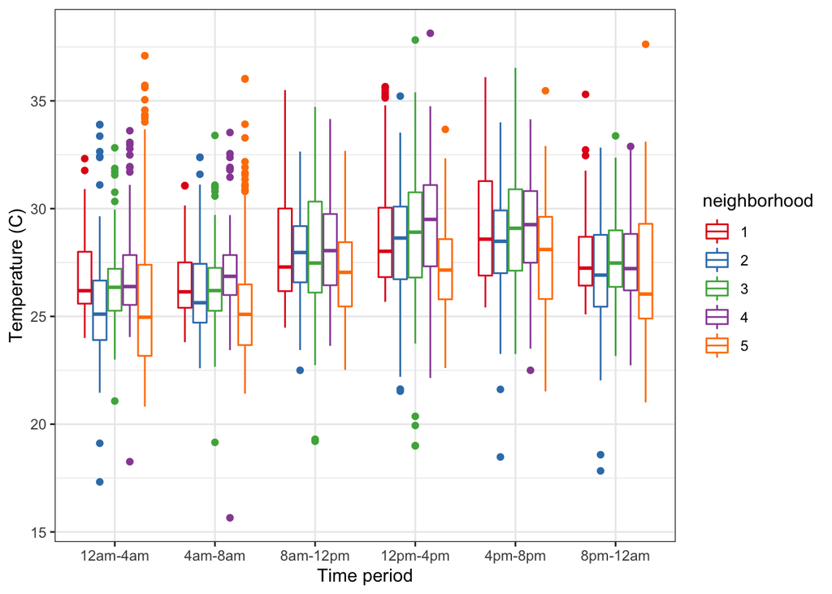

```r
# New palette of colors, add axis labels, and a cleaner theme
ggplot(IETs_nbh_time) +
  geom_boxplot(mapping = aes(x = hrs, y = temperature, color = neighborhood)) +
  scale_x_discrete(limits = c("12am-4am", "4am-8am", "8am-12pm", "12pm-4pm", "4pm-8pm", "8pm-12am")) +
  scale_color_brewer(palette = "Set1") +
  labs(x = "Time period", y = "Temperature (C)") +
  theme_bw()
```

## Summarizing differences in IETs by neighborhood by time of day

It’s often helpful to have summary statistics to report how much higher/lower one group was than another. To do this, we’ll calculate the mean and standard deviation of temperature by neighborhood, and then by neighborhood and time interval.

We’ll use the `group_by()` function to define the grouping variables to calculate summary statistics and then `summarize()` to actually calculate the statistics. When we’re calculating summary stats with `summarize()` you should always think about including `na.rm=TRUE`, which will skip `NA` values (missing values) in your dataset. The default in R is to be cautious and return `NA` if you’re doing a calculation with something that includes even one `NA` value. We’ll calculate the mean and standard deviation, and include the number of values within each group (this would be the n = ## you would report to show how many replicates your statistics represent).

```r
# GROUP BY NEIGHBORHOOD
# Group the IETs_nbh_time data frame by neighborhood
# Calculate mean temperature & standard deviation of temperature for each neighborhood, for each time period, and count the number of non-NA values
IETs_nbh_sum <- group_by(IETs_nbh_time, neighborhood) %>%
  summarize(Tmean = mean(temperature, na.rm=TRUE),
            Tsd = sd(temperature, na.rm=TRUE),
            count = n())
# Look at all the neighborhood summary
IETs_nbh_sum
```

```
## # A tibble: 5 x 4
##   neighborhood Tmean   Tsd count
##   <chr>        <dbl> <dbl> <int>
## 1 1             28.0  2.57   462
## 2 2             27.2  2.59   798
## 3 3             27.8  2.71   840
## 4 4             28.0  2.36   798
## 5 5             27.0  3.29   462
```

```r
# GROUP BY NEIGHBORHOOD & TIME PERIOD
# Group the IETs_nbh_time data frame by neighborhood and hrs
# Calculate mean temperature & standard deviation of temperature for each neighborhood, for each time period
IETs_nbh_time_sum <- group_by(IETs_nbh_time, neighborhood, hrs) %>%
  summarize(Tmean = mean(temperature, na.rm=TRUE),
            Tsd = sd(temperature, na.rm=TRUE),
            count = n())
# Look at all the summary stats of neighborhood x time period
IETs_nbh_time_sum
```

```
## # A tibble: 30 x 5
## # Groups:   neighborhood [5]
##    neighborhood hrs      Tmean   Tsd count
##    <chr>        <chr>    <dbl> <dbl> <int>
##  1 1            12am-4am  26.9  1.85    77
##  2 1            12pm-4pm  29.0  2.86    77
##  3 1            4am-8am   26.6  1.77    77
##  4 1            4pm-8pm   29.2  2.79    77
##  5 1            8am-12pm  28.3  2.83    77
##  6 1            8pm-12am  27.8  1.99    77
##  7 2            12am-4am  25.6  2.76   133
##  8 2            12pm-4pm  28.5  2.41   133
##  9 2            4am-8am   26.1  2.10   133
## 10 2            4pm-8pm   28.4  2.32   133
## # … with 20 more rows
```

```r
# Arrange data frame to find the warmest time period & neighborhood
IETs_sum_sort <- arrange(IETs_nbh_time_sum, desc(Tmean))

# Look at data frame
IETs_sum_sort
```

```
## # A tibble: 30 x 5
## # Groups:   neighborhood [5]
##    neighborhood hrs      Tmean   Tsd count
##    <chr>        <chr>    <dbl> <dbl> <int>
##  1 4            12pm-4pm  29.3  2.49   133
##  2 3            4pm-8pm   29.2  2.60   140
##  3 1            4pm-8pm   29.2  2.79    77
##  4 4            4pm-8pm   29.1  2.23   133
##  5 1            12pm-4pm  29.0  2.86    77
##  6 3            12pm-4pm  28.9  3.22   140
##  7 2            12pm-4pm  28.5  2.41   133
##  8 2            4pm-8pm   28.4  2.32   133
##  9 1            8am-12pm  28.3  2.83    77
## 10 4            8am-12pm  28.2  2.16   133
## # … with 20 more rows
```

And finally, just like we used `read_csv()` to read data into R, there is a function called `write_csv()` that will write out a csv file. This is a potentially convenient way to save a table of summary statistics.

```r
write_csv(IETs_nbh_time_sum, "data/IETs_nbh_time_sum.csv")
```

## Using an ANOVA test for signficiant differences by time of day

We can also conduct statistical tests with R, for example an Analysis of Variance (ANOVA), which could help us to test the hypothesis that the IETs should be significantly different by time of day using the `IETs_nbh_time` data frame.

```r
# Estimate an ANOVA model for the effect of the hrs group on temperature
aov_IETstime <- aov(temperature ~ hrs, data = IETs_nbh_time)

# Look at summary output from the ANOVA test
summary(aov_IETstime)
```

```
##               Df Sum Sq Mean Sq F value Pr(>F)
## hrs            5   2921   584.2   91.51 <2e-16 ***
## Residuals   3213  20513     6.4
## ---
## Signif. codes:  0 '***' 0.001 '**' 0.01 '*' 0.05 '.' 0.1 ' ' 1
## 141 observations deleted due to missingness
```

We can see that there is a significant overall effect of the time of day on temperature, from the fact that the p-value (in the `Pr(>F)` column) is less than 0.0001.

After seeing the overall estimated ANOVA model it is often helpful to compare each different time of day to the overall mean to see which times of day are significantly higher/lower than others. To do this we can do a Tukey Honest Significant Difference (HSD) test.

```r
# Run Tukey HSD test on estimated ANOVA model
TukeyHSD(aov_IETstime)
```

```
##   Tukey multiple comparisons of means
##     95% family-wise confidence level
##
## Fit: aov(formula = temperature ~ hrs, data = IETs_nbh_time)
##
## $hrs
##                          diff        lwr         upr     p adj
## 12pm-4pm-12am-4am  2.27928777  1.8389739  2.71960161 0.0000000
## 4am-8am-12am-4am   0.05868559 -0.3808037  0.49817488 0.9989647
## 4pm-8pm-12am-4am   2.38461154  1.9451222  2.82410083 0.0000000
## 8am-12pm-12am-4am  1.52031310  1.0804129  1.96021331 0.0000000
## 8pm-12am-12am-4am  1.01845041  0.5793694  1.45753144 0.0000000
## 4am-8am-12pm-4pm  -2.22060217 -2.6611200 -1.78008435 0.0000000
## 4pm-8pm-12pm-4pm   0.10532377 -0.3351941  0.54584160 0.9839917
## 8am-12pm-12pm-4pm -0.75897467 -1.1999025 -0.31804688 0.0000143
## 8pm-12am-12pm-4pm -1.26083736 -1.7009479 -0.82072684 0.0000000
## 4pm-8pm-4am-8am    2.32592594  1.8862323  2.76561960 0.0000000
## 8am-12pm-4am-8am   1.46162750  1.0215231  1.90173189 0.0000000
## 8pm-12am-4am-8am   0.95976481  0.5204792  1.39905040 0.0000000
## 8am-12pm-4pm-8pm  -0.86429844 -1.3044028 -0.42419405 0.0000003
## 8pm-12am-4pm-8pm  -1.36616113 -1.8054467 -0.92687554 0.0000000
## 8pm-12am-8am-12pm -0.50186269 -0.9415594 -0.06216598 0.0145777
```

It’s a little hard to read through all the comparisons, but we can see that most of them are significant. An alternative to the output presentation from the default `Tukey_HSD()` function is the `HSD.test()` in the `agricolae` package (you’ll need to run `install.packages("agricolae)` the first time).

```r
# Running the Tukey HSD test with agricolae
library(agricolae)
aov_IETstime <- HSD.test(aov_IETstime, trt = "hrs", alpha = 0.05)
aov_IETstime
```

```
## $statistics
##   MSerror   Df     Mean       CV
##   6.38439 3213 27.60577 9.152924
##
## $parameters
##    test name.t ntr StudentizedRange alpha
##   Tukey    hrs   6          4.03253  0.05
##
## $means
##          temperature      std   r      Min      Max      Q25      Q50
## 12am-4am    26.39756 2.691703 538 17.32294 37.09381 24.86711 25.91662
## 12pm-4pm    28.67685 2.772073 533 19.00000 38.13544 26.72222 28.55206
## 4am-8am     26.45625 2.260052 537 15.65625 36.03125 25.08400 26.13544
## 4pm-8pm     28.78217 2.547232 537 18.47906 36.53119 26.98175 28.84125
## 8am-12pm    27.91787 2.504870 535 19.20831 35.49944 26.15106 27.75000
## 8pm-12am    27.41601 2.348831 539 17.83331 37.62500 25.97916 27.12500
##               Q75
## 12am-4am 27.59111
## 12pm-4pm 30.50000
## 4am-8am  27.50000
## 4pm-8pm  30.59381
## 8am-12pm 29.61978
## 8pm-12am 28.87506
##
## $comparison
## NULL
##
## $groups
##          temperature groups
## 4pm-8pm     28.78217      a
## 12pm-4pm    28.67685      a
## 8am-12pm    27.91787      b
## 8pm-12am    27.41601      c
## 4am-8am     26.45625      d
## 12am-4am    26.39756      d
##
## attr(,"class")
## [1] "group"
```

If you scroll down to the `$groups` in the summary output, you can see that this version of the test separates significant groups with letters (a-d in this case), where different letters are significantly different groups.

You can read more about how to get relevant output from an ANOVA model and guidelines for reporting results [in this doc](https://docs.google.com/document/d/18671Z80MydBCiP1FuHTUFWI1xDNqmedHBwUSf5BJ7E8/edit?usp=sharing).

**LAB REPORT INSTRUCTIONS:**

- Identify one question that you’d like to investigate with any of the datasets from this lab.
- As you structure your data analysis to answer your question, produce an .R script pretending that you are starting from scratch (i.e., don’t assume that you have anything loaded from doing this lab exercise). The goal is to be able to hand someone your code and be able to have them re-run your analysis to see what you did and how. When you’ve finished writing your .R script, you should “Push” your respository back to GitHub following the [instructions here](https://docs.google.com/document/d/1VbVZXhnzJUY9gJbHiMn75hc8r8_zgJXct6ugEPH-Eh8/edit?usp=sharing).
- In addition to your .R script that you push to GitHub to submit, for the Lab 1 Report you will turn in a text .pdf document no longer than 2 single-spaced pages (it can be shorter!) in the format oulined within the [Lab Report Guidelines](https://docs.google.com/document/d/1BP7JYDuru8hdvQbqYwJ1s6pUWiVkBI9hmGoX8qB2eqA/edit?usp=sharing).
- Your Lab 1 Report document must include at least one ggplot figure and one summary statistic that you calculated with `group_by` and `summarize`, which counts toward the 2-page limit. You may include an ANOVA test, but you are not required to report a statistical test in this lab report.